# Dimensionality Reduction for EDA

PCA, t-SNE, UMAP, and PHATE

## Review: what made the next plot useful?

In Day 1, we moved from survivor counts to survival proportions, then added recorded sex through color.

What did each new view help us understand?

Which other passenger characteristics might matter together?

## The question now involves several variables

Which passengers have similar profiles across age, fare, family size, class, and embarkation?

How do those profiles relate to survival?

We will construct the representation using passenger characteristics, then overlay survival afterward.

## Preparation defines passenger similarity

| Input block | Preparation |
| --- | --- |
| age, fare, sibsp, parch | Median imputation, then standardization |
| pclass, sex, embarked | Most-frequent imputation, then one-hot encoding |
| survived | Withheld for interpretation |
| Missingness indicators | Withheld for a data-quality check |

The result is **891 passengers by 12 features**.

Each choice affects which passengers count as similar.

## PCA chooses directions for a projection

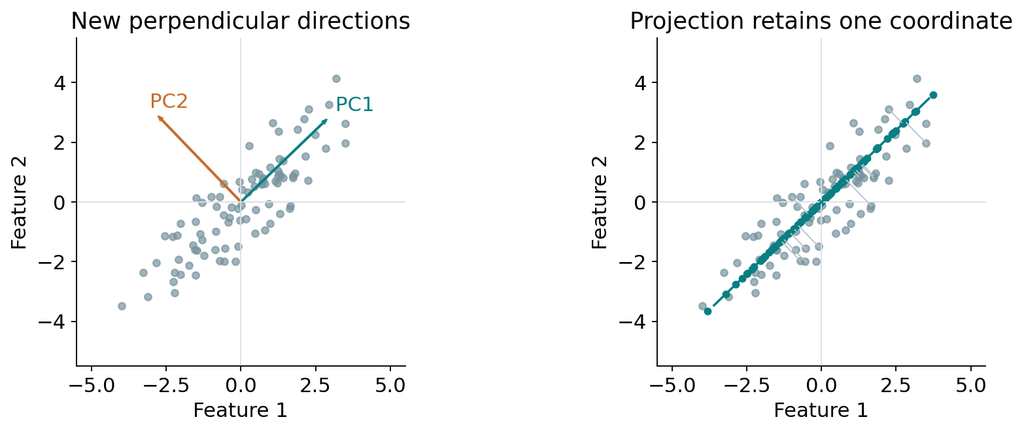

A synthetic two-variable cloud with perpendicular principal directions and its projection onto PC1.

PC1 maximizes the variance of projected coordinates. Later directions are perpendicular and capture remaining variance.

## Directions and point coordinates are different

**A component direction** gives a weight to each original feature.

**A component score** gives an observation’s coordinate along that direction.

$$z_{i1} = (x_i - \bar{x})^\top v_1$$

All passengers use the same direction. Their feature values produce different coordinates.

## SVD supplies the directions and coordinates

For the centered prepared matrix:

$$X_c = U\Sigma V^\top$$

$$Z_k = X_c V_k = U_k\Sigma_k$$

| Object | Role in this example |
| --- | --- |
| Columns of V | Component directions across the 12 features |
| First two columns of U multiplied by their singular values | Two coordinates for each of 891 passengers |
| First two columns of Z | The PCA scatterplot |

## A small score calculation

Suppose a centered observation is **(2, 1)** and a component direction is **(1, 1) divided by the square root of 2**.

$$z = \frac{2+1}{\sqrt{2}} \approx 2.12$$

That is the observation’s coordinate on this component.

What changes if we reverse the component’s direction?

## Two dimensions leave information out

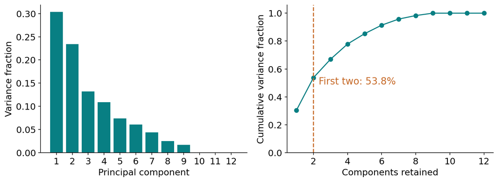

Individual and cumulative explained variance for the 12 prepared Titanic features.

The first two components retain **53.8% of prepared-feature variance** in this snapshot.

Variance retained does not measure how well we explain survival.

## Component weights help interpret the axes

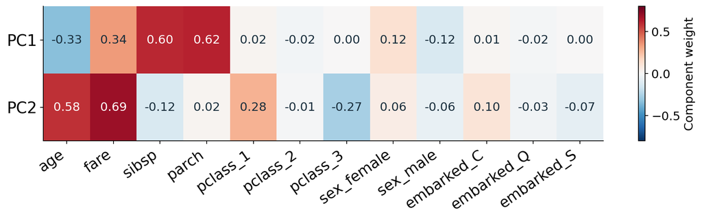

PC1 and PC2 component weights for the 12 prepared features.

Large absolute weights identify features contributing strongly to a direction.

Read the weights together with the original variables. Signs depend on axis orientation.

## Scaling changes the directions PCA chooses

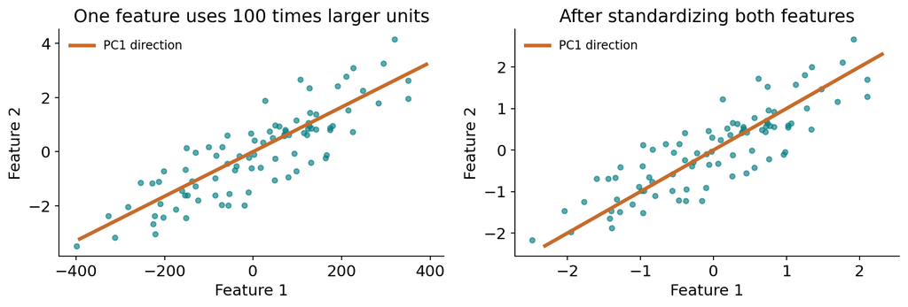

A synthetic cloud with one feature measured in much larger units and the standardized version.

PCA centers its input. It does not automatically standardize its columns.

## Quick check: the most relevant direction

PCA finds a direction with large variance across passenger characteristics.

Does that guarantee it separates survivors from nonsurvivors?

What information would PCA need to optimize separation by survival?

## t-SNE matches neighborhood similarities

1. Convert original distances into similarities, with a local scale around each point.
2. Represent similarities in the low-dimensional view using a heavy-tailed distribution.
3. Move points to make the two similarity patterns agree.

Perplexity controls an **effective neighborhood scale**. It is not an exact neighbor count.

## Perplexity changes the view

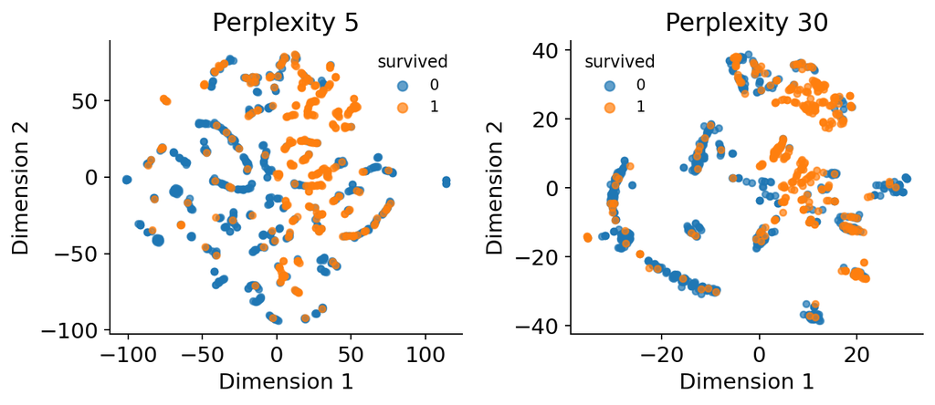

Titanic t-SNE embeddings at perplexity 5 and 30, with survival overlaid using the same palette.

The data, preparation, and coloring stay fixed. The neighborhood scale changes.

## A t-SNE island suggests a question

Which original features distinguish these observations?

Does the pattern persist with another reasonable setting or initialization?

Check the original variables before calling it a distinct group.

Island area, density, and between-island spacing need careful interpretation.

## UMAP builds a weighted neighborhood graph

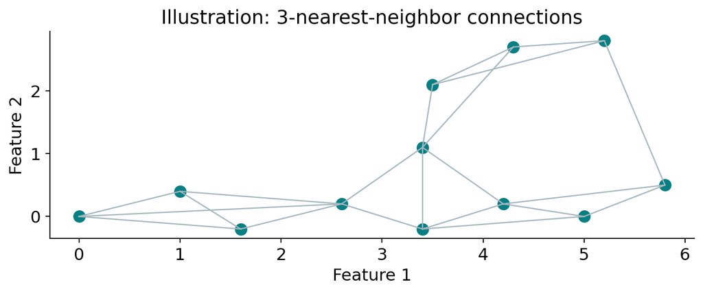

An illustrative nearest-neighbor graph on a synthetic point set.

UMAP adapts local distance scales, weights neighborhood connections, and optimizes a low-dimensional layout to represent them.

## UMAP’s parameters express different choices

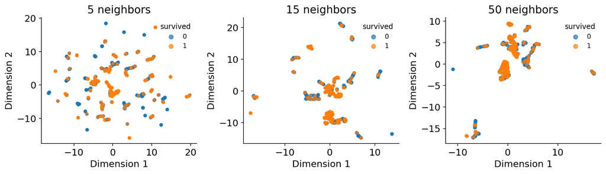

Saved UMAP reference runs with 5, 15, and 50 neighbors.

**n_neighbors:** scale of the neighborhood context.

**min_dist:** how tightly the optimized layout tends to pack points.

## PHATE compares diffusion profiles

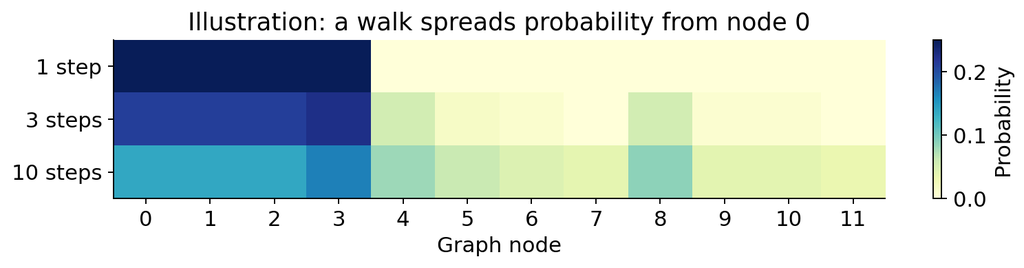

A simple graph walk spreads probability over more nodes as the number of steps increases.

PHATE builds a graph, diffuses through it, compares the resulting profiles, and lays out those relationships.

## PHATE adds a useful exploratory view

Continuous patterns and transitions are useful structures to investigate.

**knn** controls neighborhood construction.

**t** controls diffusion smoothing. We use `t="auto"` for the main example.

Diffusion steps are not observed time. A branch in Titanic does not establish a passenger trajectory.

## Live Titanic exploration

Open **`titanic_live_scaffold.ipynb`** in Positron.

Create or load the four representations, then choose one to inspect.

Keep the prepared data fixed while comparing methods.

Saved runs are supplied so we can spend time interpreting the results.

## Color is a tool for asking another question

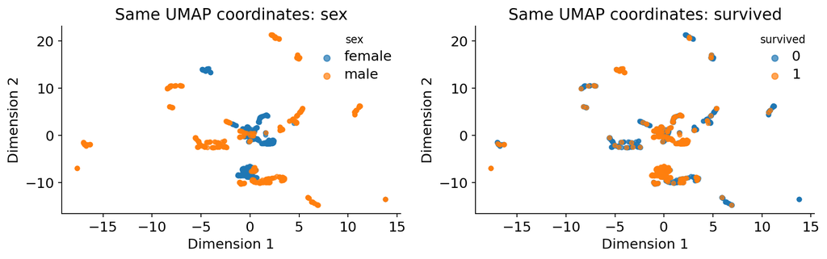

The same saved UMAP coordinates colored by recorded sex and survival.

Which overlays reflect inputs? Which add withheld information?

## An embedding leads back to the original data

Select a region and inspect the passengers behind it.

Compare their class, sex, fare, missingness, and survival with the remaining passengers.

Use an original-variable plot or table to investigate the explanation.

## Different objectives create different views

| Method | Main construction | Useful interpretation |
| --- | --- | --- |
| PCA | Linear projection retaining variance | Component weights and variance retained |
| t-SNE | Match neighborhood similarities | Local groupings to investigate |
| UMAP | Represent a weighted neighborhood graph | Neighborhood patterns at chosen scales |
| PHATE | Compare diffusion profiles | Smoother connectivity and continuous patterns |

Every view compresses information. The best next check depends on the question.

## Exit check: how strong is the claim?

“This map shows three islands, so there are three kinds of passengers.”

What would you check before accepting that claim?

Name one original-variable comparison and one sensitivity check.

## Extra practice: tornado profiles

Open **`tornado_practice.ipynb`**.

Use the fixed 700-record sample. Construct profiles using transformed track size and starting location.

Overlay EF rating, which was withheld from the embedding inputs.

Then compare with the original size measurements. How does including geography change the meaning of similarity?

## Appendix: SVD and covariance eigenvectors

$$\frac{X_c^\top X_c}{n-1} = V\frac{\Sigma^2}{n-1}V^\top$$

$$\lambda_j = \frac{\sigma_j^2}{n-1}$$

The right singular vectors are covariance eigenvectors. Singular values determine the variance along each component.

## Appendix: UMAP layout compactness

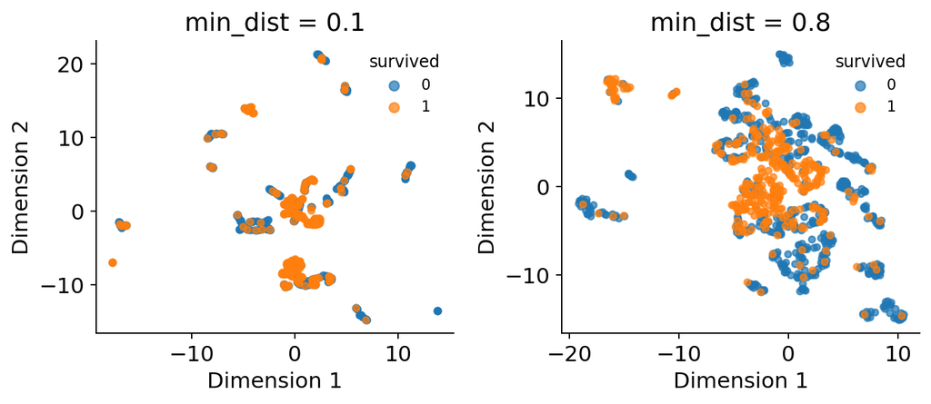

Saved UMAP runs with min_dist 0.1 and 0.8 while other main settings stay fixed.

Compactness in the layout depends partly on the parameter choice.

## Appendix: PHATE diffusion smoothing

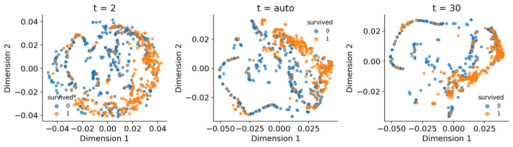

Actual PHATE runs using t=2, automatic t, and t=30 with the same prepared Titanic features and survival colors.

The diffusion scale changes which patterns remain visible.

## Sources and run details

- [scikit-learn PCA](https://scikit-learn.org/stable/modules/generated/sklearn.decomposition.PCA.html)
- [scikit-learn t-SNE](https://scikit-learn.org/stable/modules/manifold.html#t-distributed-stochastic-neighbor-embedding-t-sne)
- [UMAP documentation](https://umap-learn.readthedocs.io/en/latest/)
- [PHATE documentation](https://phate.readthedocs.io/en/stable/)
- Moon et al. (2019), *Nature Biotechnology*, [doi:10.1038/s41587-019-0336-3](https://doi.org/10.1038/s41587-019-0336-3)

The website includes dataset preparation, exact settings, and saved-run provenance.